# R Notebook

```r
library(rpart)
library(rpart.plot)
library(tidyverse)

library(tidyverse)
titanic_set <- read_csv('data/titanic_decision_tree_data.csv')
```

```
* `` -> ...1
```

```r
shuffle_index <- sample(1:nrow(titanic_set))

# shuffle the data so class order isn't in order - need this for training/testing split later on
titanic_set <- titanic_set[shuffle_index, ]
```

```r
glimpse(titanic_set)
```

```
Rows: 1,309
Columns: 13
$ ...1         <dbl> 778, 1019, 971, 175, 931, 1133, 156, 861, 664, 1218, 978, 1193, 818, 36, 1067, 359, 1306, 339,…
$ passenger_id <dbl> 360, 601, 553, 1066, 513, 715, 1047, 443, 246, 800, 560, 775, 400, 927, 649, 1250, 888, 1230, …
$ pclass       <dbl> 3, 2, 3, 3, 1, 2, 3, 3, 1, 3, 3, 2, 2, 3, 3, 3, 1, 2, 1, 2, 2, 1, 2, 3, 3, 2, 2, 2, 3, 1, 3, 3…
$ name         <chr> "Mockler, Miss. Helen Mary \"Ellie\"", "Jacobsohn, Mrs. Sidney Samuel (Amy Frances Christy)", …
$ sex          <chr> "female", "female", "male", "male", "male", "male", "male", "male", "male", "female", "female"…
$ age          <dbl> NA, 24.00, NA, 40.00, 36.00, 52.00, 24.00, 25.00, 44.00, 30.00, 36.00, 54.00, 28.00, 18.50, NA…
$ sib_sp       <dbl> 0, 2, 0, 1, 0, 0, 0, 1, 2, 1, 1, 1, 0, 0, 0, 0, 0, 0, 1, 0, 0, 1, 0, 0, 0, 1, 0, 0, 0, 0, 0, 1…
$ parch        <dbl> 0, 1, 0, 5, 0, 0, 0, 0, 0, 1, 0, 3, 0, 0, 0, 0, 0, 0, 4, 0, 0, 0, 0, 0, 0, 1, 0, 2, 0, 1, 0, 0…
$ ticket       <chr> "330980", "243847", "330979", "347077", "PC 17473", "250647", "S.O./P.P. 752", "347076", "1992…
$ fare         <dbl> 7.8792, 27.0000, 7.8292, 31.3875, 26.2875, 13.0000, 7.5500, 7.7750, 90.0000, 24.1500, 17.4000,…
$ cabin        <chr> NA, NA, NA, NA, "E25", NA, NA, NA, "C78", NA, NA, NA, NA, NA, NA, NA, "B42", NA, "C23 C25 C27"…
$ embarked     <chr> "Q", "S", "Q", "S", "S", "S", "S", "S", "Q", "S", "S", "S", "S", "C", "S", "Q", "S", "S", "S",…
$ survived     <dbl> 1, 1, 0, NA, 1, 0, NA, 0, 0, 0, 1, 1, 1, NA, 0, NA, 1, NA, NA, 1, 0, NA, 1, 0, 0, 1, NA, 1, 0,…
```

```r
titanic_clean <- titanic_set %>%
  mutate(sex = as.factor(sex),
         survived = factor(survived, levels = c(0,1), labels = c("No", "Yes")),
         class = factor(pclass, levels = c(3,2,1), labels = c("Lower", "Middle", "Upper")),
         embarked = as.factor(embarked),
         age_status = as.factor(if_else(age < 17, "child", "adult"))) %>%
    select(-c(...1, passenger_id, name, ticket, fare, cabin, age, pclass)) %>%
    na.omit()
```

```r
glimpse(titanic_clean)
```

```
Rows: 712
Columns: 7
$ sex        <fct> female, male, male, male, male, female, female, female, female, female, female, male, female, fe…
$ sib_sp     <dbl> 2, 0, 0, 1, 2, 1, 1, 1, 0, 0, 0, 0, 0, 0, 1, 0, 0, 0, 1, 0, 0, 0, 0, 0, 0, 1, 3, 2, 0, 0, 0, 0, …
$ parch      <dbl> 1, 0, 0, 0, 0, 1, 0, 3, 0, 0, 0, 0, 0, 0, 1, 2, 0, 1, 0, 0, 0, 0, 0, 0, 0, 0, 1, 1, 0, 0, 0, 1, …
$ embarked   <fct> S, S, S, S, Q, S, S, S, S, S, S, S, S, S, S, S, S, C, S, S, S, S, S, C, S, S, S, S, S, S, C, C, …
$ survived   <fct> Yes, Yes, No, No, No, No, Yes, Yes, Yes, Yes, Yes, No, Yes, No, Yes, Yes, No, No, No, No, No, No…
$ class      <fct> Middle, Upper, Middle, Lower, Upper, Lower, Lower, Middle, Middle, Upper, Middle, Middle, Middle…
$ age_status <fct> adult, adult, adult, adult, adult, adult, adult, adult, adult, adult, adult, adult, adult, adult…
```

## Looking at data and creating some plots to know what I’m working with

[output not shown]

[output cut: 20 more lines]

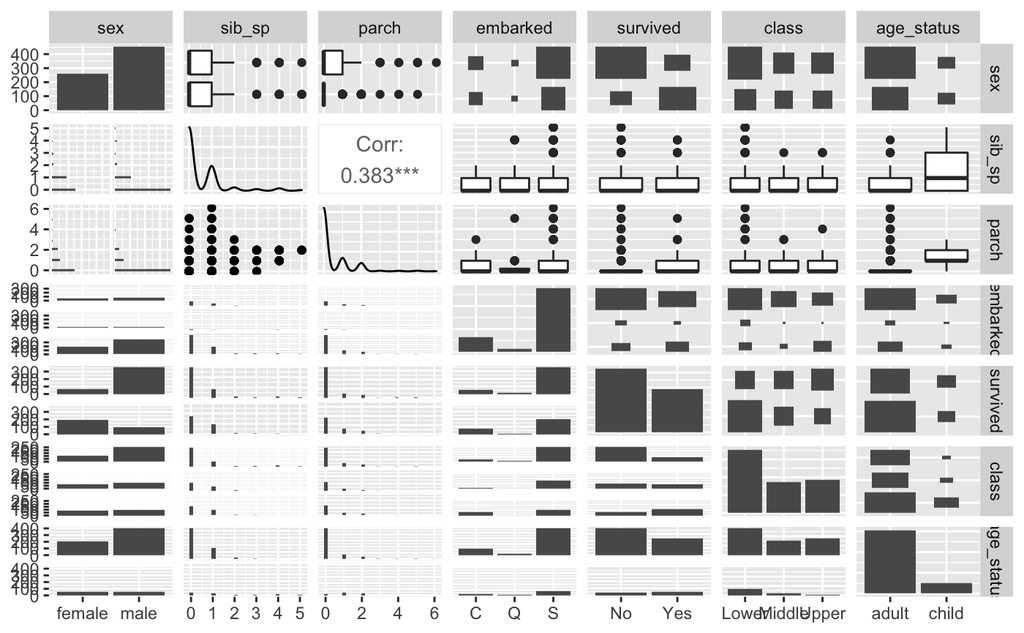

```r
library(GGally)

ggpairs(titanic_clean)
```

[output not shown]

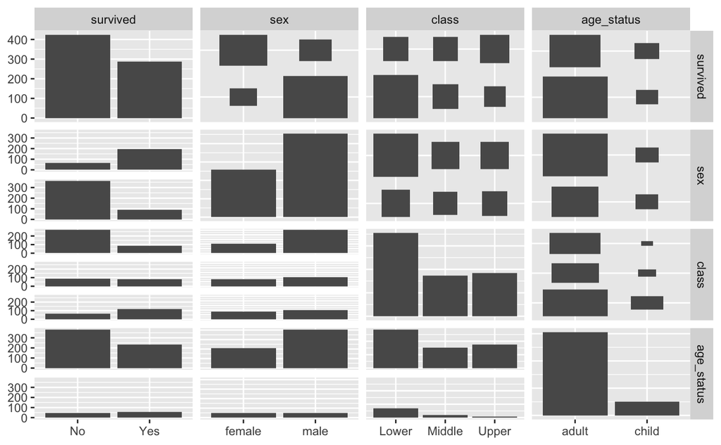

```r
titanic_clean %>%
  select(survived, sex, class, age_status) %>%
  ggpairs()
```

The variables selected in the second set of `ggpairs` plots are the ones I think are most useful to predict whether people survive or not

## Create testing and training sets

```r
n_data <- nrow(titanic_clean)

test_index <- sample(1:n_data, size = n_data*0.2)

titanic_test  <- slice(titanic_clean, test_index)

titanic_train <- slice(titanic_clean, -test_index)
```

Chose a 80/20 training/testing split as I’m not sure a 10% test set will have enough data to accurately measure the model performance

```r
titanic_test %>%
  janitor::tabyl(survived)
```

```
 survived  n   percent
       No 86 0.6056338
      Yes 56 0.3943662
```

```r
titanic_train %>%
  janitor::tabyl(survived)
```

```
 survived   n   percent
       No 338 0.5929825
      Yes 232 0.4070175
```

## Create decision tree to try and predict survival probability using an appropriate method, and create a decision tree plot.

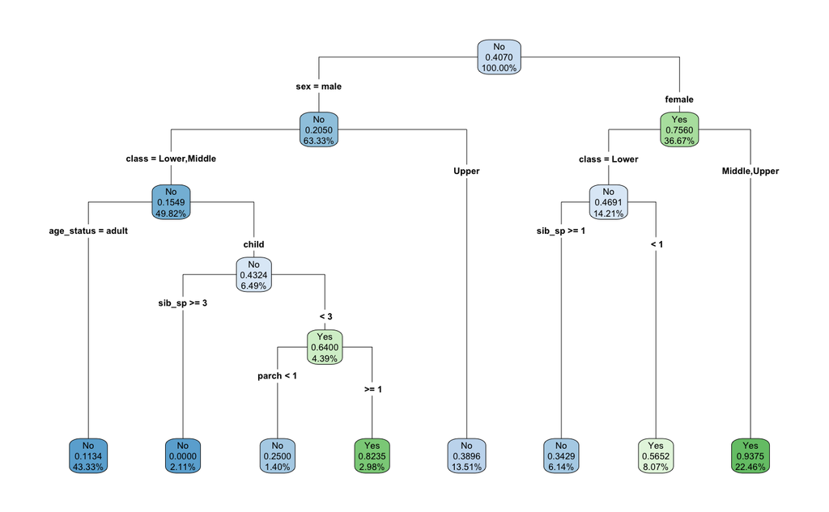

```r
titanic_fit <- rpart(
  formula = survived ~.,
  data = titanic_train,
  method = "class"
)

rpart.plot(titanic_fit,
           yesno = 2,
           fallen.leaves = TRUE,
           faclen = 6,
           digits = 4,
           type = 4)
```

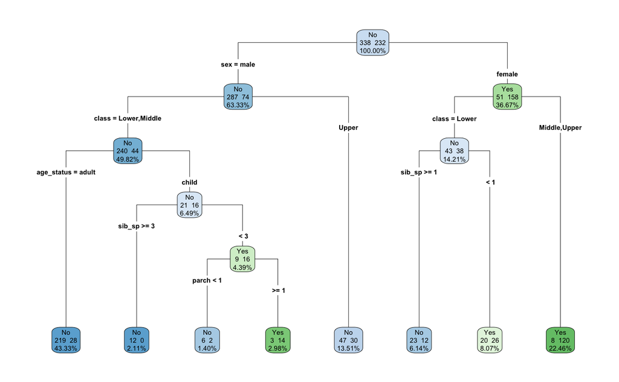

```r
rpart.plot(titanic_fit,
           yesno = 2,
           fallen.leaves = TRUE,
           faclen = 6,
           digits = 4,
           type = 4,
           extra = 101)
```

The most important variable is the sex followed by class. For each node: * the first line tells you whether they’re predicted to survive or not * second line is the probabilty of survival (first plot) * second line is a breakdown of deaths, number on left, and survivors, number on right (second plot) * third line is the percentage of the data that passes through the node

## Test and add predictions to data

```r
library(modelr)
```

[output not shown]

[output cut: 132 more lines]

```r
library(caret)
confusionMatrix(titanic_test_pred$pred, titanic_test_pred$survived)
```

```
Confusion Matrix and Statistics

          Reference
Prediction No Yes
       No  80  21
       Yes  6  35

               Accuracy : 0.8099
                 95% CI : (0.7355, 0.8708)
    No Information Rate : 0.6056
    P-Value [Acc > NIR] : 1.437e-07

                  Kappa : 0.5824

 Mcnemar's Test P-Value : 0.007054

            Sensitivity : 0.9302
            Specificity : 0.6250
         Pos Pred Value : 0.7921
         Neg Pred Value : 0.8537
             Prevalence : 0.6056
         Detection Rate : 0.5634
   Detection Prevalence : 0.7113
      Balanced Accuracy : 0.7776

       'Positive' Class : No
```

The model created was 81% accurate in predicting whether a passenger survived in the test set. The sensitivity of the model (true positive rate) is 0.93 and the specificity (true negative rate) is 0.62